# ConcreteStrengthPrediction - Brandon Smith

Concrete Strength Prediction

### Attribute Information:

Given are the variable name, variable type, the measurement unit, and a brief description. The concrete compressive strength is the regression problem. The order of this listing corresponds to the order of numerals along the rows of the database.

- Cement - kg in a m3 mixture (input variable)
- Blast Furnace Slag - kg in a m3 mixture (input variable)
- Fly Ash - kg in a m3 mixture (input variable)
- Water - kg in a m3 mixture (input variable)
- Superplasticizer - kg in a m3 mixture (input variable)
- Coarse Aggregate - kg in a m3 mixture (input variable)
- Fine Aggregate - kg in a m3 mixture (input variable)
- Age - day (1 - 365) (input variable)
- Concrete compressive strength - MPa (output variable)

### Objective:

To predict the concrete strength using the data available in file "concrete.csv". Apply feature engineering and model tuning to obtain 85% to 95% accuracy.

#### Brandon Smith

10/17/2020

### 1. Import Necessary Packages:

```python
#Import pandas
import pandas as pd
#Import numpy
import numpy as np
#Import seaborn
import seaborn as sns
#Import motplotlib
import matplotlib.pyplot as plt
%matplotlib inline

#Import sklearn packages
from sklearn.linear_model import LinearRegression
from sklearn.linear_model import LogisticRegression
from sklearn.metrics import mean_squared_error
from sklearn.preprocessing import StandardScaler
from sklearn.decomposition import PCA
from sklearn.pipeline import Pipeline
from sklearn.model_selection import GridSearchCV
from sklearn.model_selection import train_test_split
from sklearn.model_selection import KFold
from sklearn.model_selection import cross_val_score
from sklearn.svm import SVC

from sklearn.ensemble import GradientBoostingRegressor
from sklearn.ensemble import BaggingRegressor
from sklearn.ensemble import AdaBoostRegressor
from sklearn.ensemble import RandomForestRegressor
from sklearn.metrics import accuracy_score, f1_score, recall_score, precision_score, confusion_matrix, mean_squared_error, roc_auc_score, roc_curve
from sklearn.model_selection import RandomizedSearchCV
from sklearn.datasets import load_digits

from scipy.stats import randint as sp_randint
```

```python
#Filter out warnings
import warnings
warnings.filterwarnings('ignore')
```

```python
#display all the columns instead of cutting off
pd.options.display.max_columns = None
```

### 2. Import Data from CSV into DataFrame:

```python
#Import the excel data
concrete_data = pd.read_csv('concrete.csv')
display(concrete_data)
```

|  | cement | slag | ash | water | superplastic | coarseagg | fineagg | age | strength |
| --- | --- | --- | --- | --- | --- | --- | --- | --- | --- |
| 0 | 141.3 | 212.0 | 0.0 | 203.5 | 0.0 | 971.8 | 748.5 | 28 | 29.89 |
| 1 | 168.9 | 42.2 | 124.3 | 158.3 | 10.8 | 1080.8 | 796.2 | 14 | 23.51 |
| 2 | 250.0 | 0.0 | 95.7 | 187.4 | 5.5 | 956.9 | 861.2 | 28 | 29.22 |
| 3 | 266.0 | 114.0 | 0.0 | 228.0 | 0.0 | 932.0 | 670.0 | 28 | 45.85 |
| 4 | 154.8 | 183.4 | 0.0 | 193.3 | 9.1 | 1047.4 | 696.7 | 28 | 18.29 |
| ... | ... | ... | ... | ... | ... | ... | ... | ... | ... |
| 1025 | 135.0 | 0.0 | 166.0 | 180.0 | 10.0 | 961.0 | 805.0 | 28 | 13.29 |
| 1026 | 531.3 | 0.0 | 0.0 | 141.8 | 28.2 | 852.1 | 893.7 | 3 | 41.30 |
| 1027 | 276.4 | 116.0 | 90.3 | 179.6 | 8.9 | 870.1 | 768.3 | 28 | 44.28 |
| 1028 | 342.0 | 38.0 | 0.0 | 228.0 | 0.0 | 932.0 | 670.0 | 270 | 55.06 |
| 1029 | 540.0 | 0.0 | 0.0 | 173.0 | 0.0 | 1125.0 | 613.0 | 7 | 52.61 |

1030 rows × 9 columns

### 3. Apply info, shape, describe, and find the number of missing values in the data:

```python
#information about data
concrete_data.info()
```

```
<class 'pandas.core.frame.DataFrame'>
RangeIndex: 1030 entries, 0 to 1029
Data columns (total 9 columns):
 #   Column        Non-Null Count  Dtype
---  ------        --------------  -----
 0   cement        1030 non-null   float64
 1   slag          1030 non-null   float64
 2   ash           1030 non-null   float64
 3   water         1030 non-null   float64
 4   superplastic  1030 non-null   float64
 5   coarseagg     1030 non-null   float64
 6   fineagg       1030 non-null   float64
 7   age           1030 non-null   int64
 8   strength      1030 non-null   float64
dtypes: float64(8), int64(1)
memory usage: 72.5 KB
```

```python
#shape of data
concrete_data.shape
```

```
(1030, 9)
```

```python
#data describe
concrete_data.describe()
```

|  | cement | slag | ash | water | superplastic | coarseagg | fineagg | age | strength |
| --- | --- | --- | --- | --- | --- | --- | --- | --- | --- |
| count | 1030.000000 | 1030.000000 | 1030.000000 | 1030.000000 | 1030.000000 | 1030.000000 | 1030.000000 | 1030.000000 | 1030.000000 |
| mean | 281.167864 | 73.895825 | 54.188350 | 181.567282 | 6.204660 | 972.918932 | 773.580485 | 45.662136 | 35.817961 |
| std | 104.506364 | 86.279342 | 63.997004 | 21.354219 | 5.973841 | 77.753954 | 80.175980 | 63.169912 | 16.705742 |
| min | 102.000000 | 0.000000 | 0.000000 | 121.800000 | 0.000000 | 801.000000 | 594.000000 | 1.000000 | 2.330000 |
| 25% | 192.375000 | 0.000000 | 0.000000 | 164.900000 | 0.000000 | 932.000000 | 730.950000 | 7.000000 | 23.710000 |
| 50% | 272.900000 | 22.000000 | 0.000000 | 185.000000 | 6.400000 | 968.000000 | 779.500000 | 28.000000 | 34.445000 |
| 75% | 350.000000 | 142.950000 | 118.300000 | 192.000000 | 10.200000 | 1029.400000 | 824.000000 | 56.000000 | 46.135000 |
| max | 540.000000 | 359.400000 | 200.100000 | 247.000000 | 32.200000 | 1145.000000 | 992.600000 | 365.000000 | 82.600000 |

```python
#check for null values
concrete_data.isnull().sum()
```

```
cement          0
slag            0
ash             0
water           0
superplastic    0
coarseagg       0
fineagg         0
age             0
strength        0
dtype: int64
```

```python
#check for is na values
concrete_data.isna().sum()
```

```
cement          0
slag            0
ash             0
water           0
superplastic    0
coarseagg       0
fineagg         0
age             0
strength        0
dtype: int64
```

```python
#check overall correlation
concrete_data.corr()

#Analysis - it looks like there is correlation between cement and strength, superplasic and strength
#and age and strength by looking at the following data.
```

|  | cement | slag | ash | water | superplastic | coarseagg | fineagg | age | strength |
| --- | --- | --- | --- | --- | --- | --- | --- | --- | --- |
| cement | 1.000000 | -0.275216 | -0.397467 | -0.081587 | 0.092386 | -0.109349 | -0.222718 | 0.081946 | 0.497832 |
| slag | -0.275216 | 1.000000 | -0.323580 | 0.107252 | 0.043270 | -0.283999 | -0.281603 | -0.044246 | 0.134829 |
| ash | -0.397467 | -0.323580 | 1.000000 | -0.256984 | 0.377503 | -0.009961 | 0.079108 | -0.154371 | -0.105755 |
| water | -0.081587 | 0.107252 | -0.256984 | 1.000000 | -0.657533 | -0.182294 | -0.450661 | 0.277618 | -0.289633 |
| superplastic | 0.092386 | 0.043270 | 0.377503 | -0.657533 | 1.000000 | -0.265999 | 0.222691 | -0.192700 | 0.366079 |
| coarseagg | -0.109349 | -0.283999 | -0.009961 | -0.182294 | -0.265999 | 1.000000 | -0.178481 | -0.003016 | -0.164935 |
| fineagg | -0.222718 | -0.281603 | 0.079108 | -0.450661 | 0.222691 | -0.178481 | 1.000000 | -0.156095 | -0.167241 |
| age | 0.081946 | -0.044246 | -0.154371 | 0.277618 | -0.192700 | -0.003016 | -0.156095 | 1.000000 | 0.328873 |
| strength | 0.497832 | 0.134829 | -0.105755 | -0.289633 | 0.366079 | -0.164935 | -0.167241 | 0.328873 | 1.000000 |

### 4. Clean up Data

```python
#left data as given and will use standard scaler on in the pipeline
```

### 5. Univariate Analysis

#### Cement

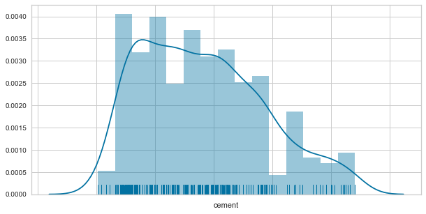

```python
#get a high level veiw of the cement data
plt.figure(figsize=(10,5));
chart = sns.distplot(concrete_data['cement'],kde=True, rug=True);
chart.set_xticklabels(
    chart.get_xticklabels(),
    rotation=55,
    horizontalalignment='right',
    fontweight='light',
    fontsize='medium'
);
plt.show();
```

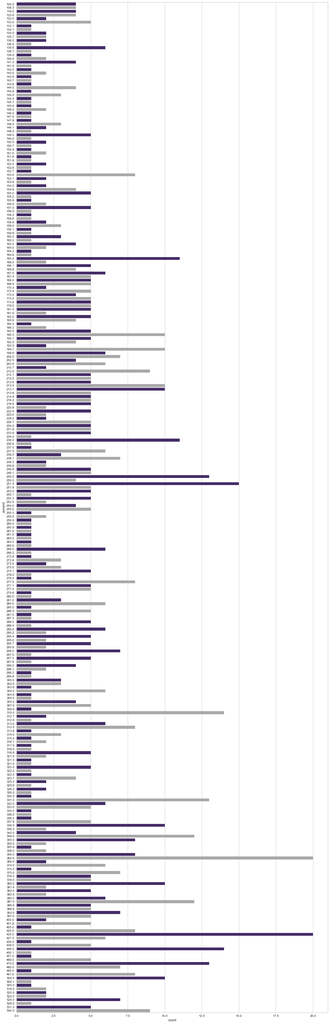

```python
#get a quick close up of the visual for cement data
plt.figure(figsize=(18,60));
chart = sns.countplot( y =concrete_data['cement'], palette=['#432371',"#A9A9A9"]);
plt.show();
```

```python
#get cement value counts
concrete_data.cement.value_counts()
```

```
425.0    20
362.6    20
251.4    15
446.0    14
310.0    14
         ..
312.9     1
261.9     1
325.6     1
143.8     1
145.4     1
Name: cement, Length: 278, dtype: int64
```

#### Slag

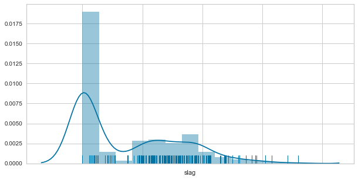

```python
#get a high level veiw of the slag data
plt.figure(figsize=(10,5));
chart = sns.distplot(concrete_data['slag'],kde=True, rug=True);
chart.set_xticklabels(
    chart.get_xticklabels(),
    rotation=55,
    horizontalalignment='right',
    fontweight='light',
    fontsize='medium'
);
plt.show();
```

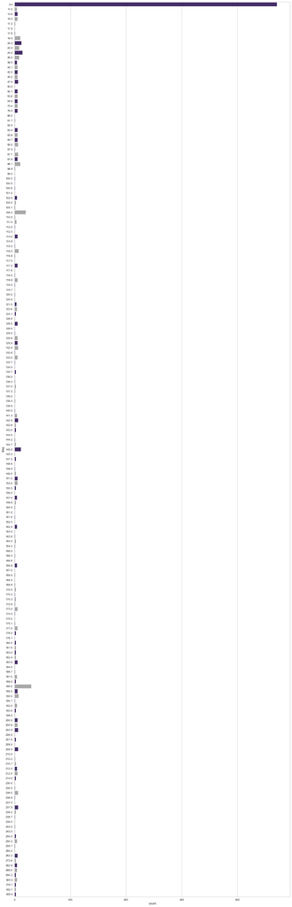

```python
#get a quick close up of the visual for slag data
plt.figure(figsize=(18,60));
chart = sns.countplot(y = concrete_data['slag'], palette=['#432371',"#A9A9A9"]);
plt.show();
```

#### Ash

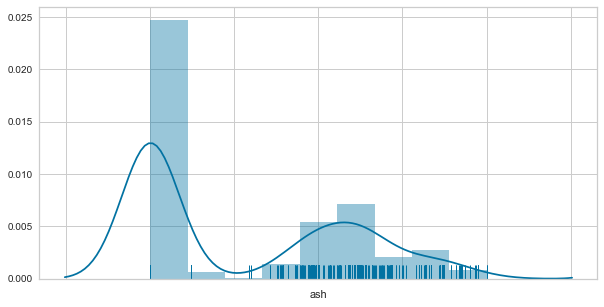

```python
#get a high level veiw of the ash data
plt.figure(figsize=(10,5));
chart = sns.distplot(concrete_data['ash'],kde=True, rug=True);
chart.set_xticklabels(
    chart.get_xticklabels(),
    rotation=55,
    horizontalalignment='right',
    fontweight='light',
    fontsize='medium'
);
plt.show();
```

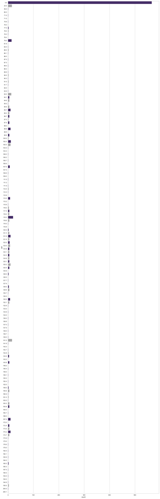

```python
#get a quick close up of the visual for ash data
plt.figure(figsize=(18,60));
chart = sns.countplot(y = concrete_data['ash'], palette=['#432371',"#A9A9A9"]);
plt.show();
```

#### Water

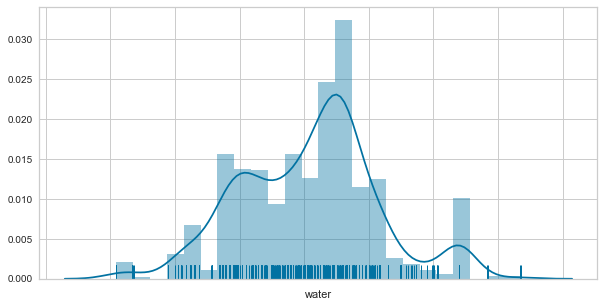

```python
#get a high level veiw of the water data
plt.figure(figsize=(10,5));
chart = sns.distplot(concrete_data['water'],kde=True, rug=True);
chart.set_xticklabels(
    chart.get_xticklabels(),
    rotation=55,
    horizontalalignment='right',
    fontweight='light',
    fontsize='medium'
);
plt.show();
```

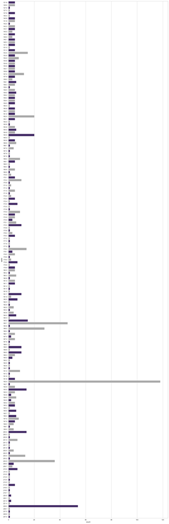

```python
#get a quick close up of the visual for water data
plt.figure(figsize=(18,60));
chart = sns.countplot(y = concrete_data['water'], palette=['#432371',"#A9A9A9"]);
plt.show();
```

#### Superplastic

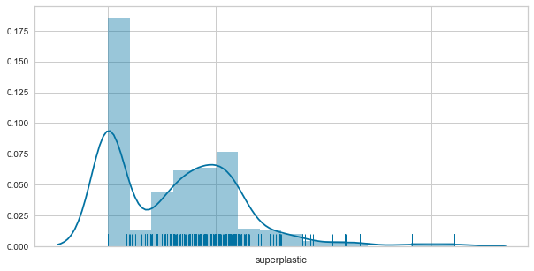

```python
#get a high level veiw of the superplastic data
plt.figure(figsize=(10,5));
chart = sns.distplot(concrete_data['superplastic'],kde=True, rug=True);
chart.set_xticklabels(
    chart.get_xticklabels(),
    rotation=55,
    horizontalalignment='right',
    fontweight='light',
    fontsize='medium'
);
plt.show();
```

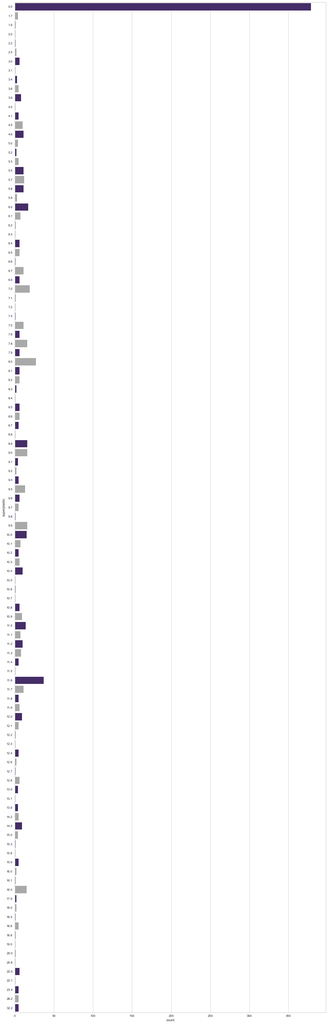

```python
#get a quick close up of the visual for superplastic data
plt.figure(figsize=(18,60));
chart = sns.countplot(y = concrete_data['superplastic'], palette=['#432371',"#A9A9A9"]);
plt.show();
```

#### Coarseagg

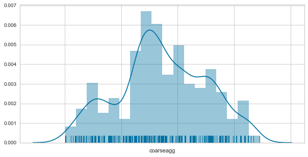

```python
#get a high level veiw of the coarseagg data
plt.figure(figsize=(10,5));
chart = sns.distplot(concrete_data['coarseagg'],kde=True, rug=True);
chart.set_xticklabels(
    chart.get_xticklabels(),
    rotation=55,
    horizontalalignment='right',
    fontweight='light',
    fontsize='medium'
);
plt.show();
```

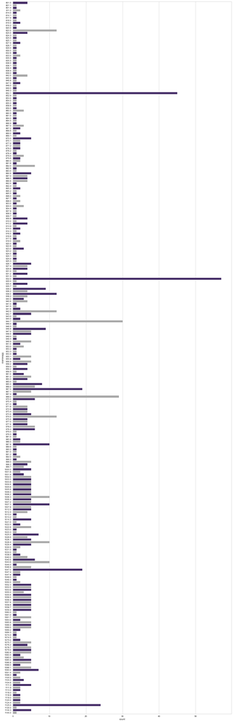

```python
#get a quick close up of the visual for coarseagg data
plt.figure(figsize=(18,60));
chart = sns.countplot(y = concrete_data['coarseagg'], palette=['#432371',"#A9A9A9"]);
plt.show();
```

#### Fineagg

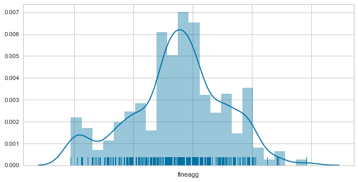

```python
#get a high level veiw of the fineagg data
plt.figure(figsize=(10,5));
chart = sns.distplot(concrete_data['fineagg'],kde=True, rug=True);
chart.set_xticklabels(
    chart.get_xticklabels(),
    rotation=55,
    horizontalalignment='right',
    fontweight='light',
    fontsize='medium'
);
plt.show();
```

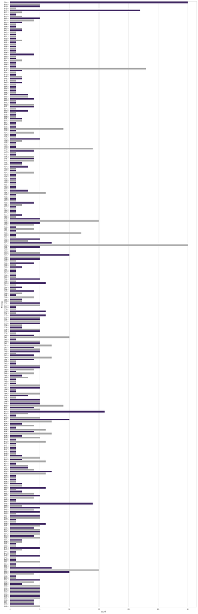

```python
#get a quick close up of the visual for fineagg data
plt.figure(figsize=(18,60));
chart = sns.countplot(y = concrete_data['fineagg'], palette=['#432371',"#A9A9A9"]);
plt.show();
```

#### Age

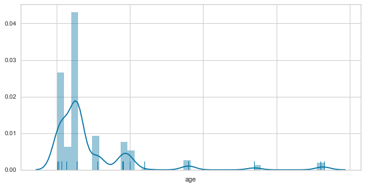

```python
#get a high level veiw of the age data
plt.figure(figsize=(10,5));
chart = sns.distplot(concrete_data['age'],kde=True, rug=True);
chart.set_xticklabels(
    chart.get_xticklabels(),
    rotation=55,
    horizontalalignment='right',
    fontweight='light',
    fontsize='medium'
);
plt.show();
```

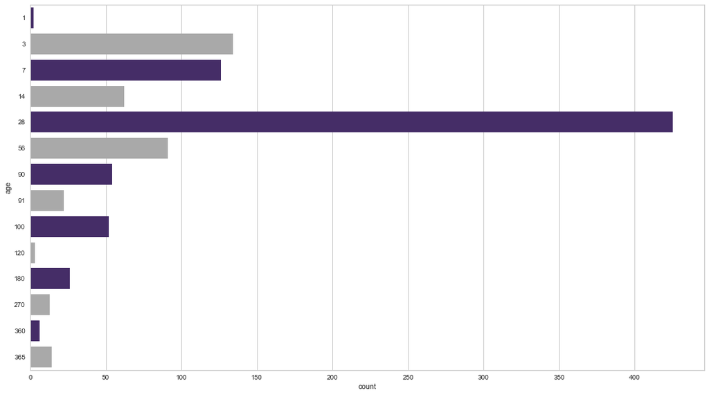

```python
#get a quick close up of the visual for age data
plt.figure(figsize=(18,10));
chart = sns.countplot(y = concrete_data['age'], palette=['#432371',"#A9A9A9"]);
plt.show();
```

```python
#Get value counts for the age data
concrete_data.age.value_counts()
```

```
28     425
3      134
7      126
56      91
14      62
90      54
100     52
180     26
91      22
365     14
270     13
360      6
120      3
1        2
Name: age, dtype: int64
```

#### Strength

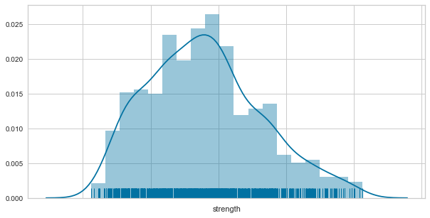

```python
#get a high level veiw of the strength data
plt.figure(figsize=(10,5));
chart = sns.distplot(concrete_data['strength'],kde=True, rug=True);
chart.set_xticklabels(
    chart.get_xticklabels(),
    rotation=55,
    horizontalalignment='right',
    fontweight='light',
    fontsize='medium'
);
plt.show();
```

[figure not shown]

```python
#get a quick close up of the visual for strength data
plt.figure(figsize=(18,120));
chart = sns.countplot(y = concrete_data['strength'], palette=['#432371',"#A9A9A9"]);
plt.show();
```

```python
concrete_data.strength.value_counts()
```

```
33.40    6
79.30    4
41.05    4
71.30    4
35.30    4
        ..
61.23    1
26.31    1
38.63    1
47.74    1
15.75    1
Name: strength, Length: 845, dtype: int64
```

### 6. Multivariate Analysis

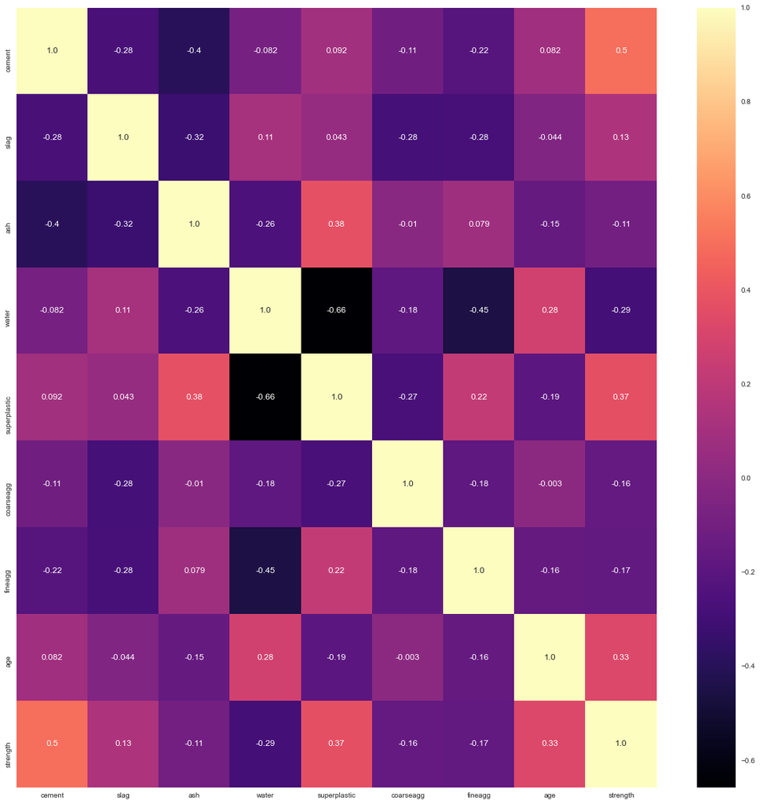

```python
#TODO
plt.figure(figsize=(20,20))
sns.heatmap(concrete_data.corr(),annot=True,fmt=".2",cmap='magma')
plt.show()

#Analysis: there seems to be correlation with cement, age and superplastic with strength
```

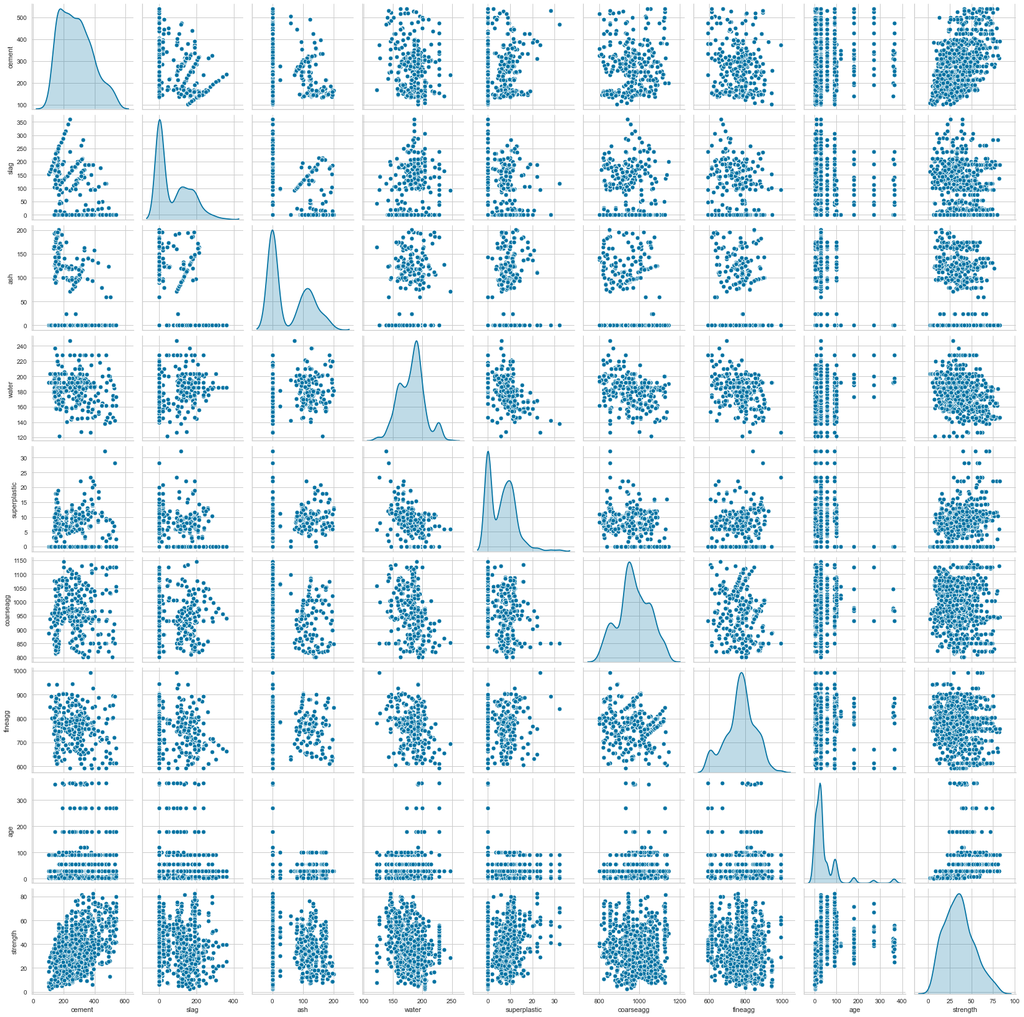

```python
sns.pairplot(concrete_data, diag_kind = 'kde',palette='mako');
plt.show();
```

### 7. Prepare and Split Data

```python
#make copy of the data for working with to prevent altering
prepared_concrete_data = concrete_data.copy()
```

```python
#split into X & y
X = prepared_concrete_data.drop("strength" , axis=1)
y = prepared_concrete_data['strength']
```

```python
#split the training data and test data at 70% / 30%
X_train, X_test, y_train, y_test = train_test_split(X, y, test_size=.3, random_state=7)
```

```python
#split the test data into the test data and vaidation data at .5 so 15% each of the total dataset size
X_test, X_valid, y_test, y_valid = train_test_split(X_test, y_test, test_size=.5, random_state=7)
```

```python
#verify the copied data frame info
prepared_concrete_data.info()
```

```
<class 'pandas.core.frame.DataFrame'>
RangeIndex: 1030 entries, 0 to 1029
Data columns (total 9 columns):
 #   Column        Non-Null Count  Dtype
---  ------        --------------  -----
 0   cement        1030 non-null   float64
 1   slag          1030 non-null   float64
 2   ash           1030 non-null   float64
 3   water         1030 non-null   float64
 4   superplastic  1030 non-null   float64
 5   coarseagg     1030 non-null   float64
 6   fineagg       1030 non-null   float64
 7   age           1030 non-null   int64
 8   strength      1030 non-null   float64
dtypes: float64(8), int64(1)
memory usage: 72.5 KB
```

#### Training Dataset Information

```python
#verify that the training set has 70% of the total value
X_train.info()
```

```
<class 'pandas.core.frame.DataFrame'>
Int64Index: 721 entries, 459 to 175
Data columns (total 8 columns):
 #   Column        Non-Null Count  Dtype
---  ------        --------------  -----
 0   cement        721 non-null    float64
 1   slag          721 non-null    float64
 2   ash           721 non-null    float64
 3   water         721 non-null    float64
 4   superplastic  721 non-null    float64
 5   coarseagg     721 non-null    float64
 6   fineagg       721 non-null    float64
 7   age           721 non-null    int64
dtypes: float64(7), int64(1)
memory usage: 50.7 KB
```

#### Validation Datset Information

```python
#verify that the validation set has 15% of the total value
X_valid.info()
```

```
<class 'pandas.core.frame.DataFrame'>
Int64Index: 155 entries, 98 to 620
Data columns (total 8 columns):
 #   Column        Non-Null Count  Dtype
---  ------        --------------  -----
 0   cement        155 non-null    float64
 1   slag          155 non-null    float64
 2   ash           155 non-null    float64
 3   water         155 non-null    float64
 4   superplastic  155 non-null    float64
 5   coarseagg     155 non-null    float64
 6   fineagg       155 non-null    float64
 7   age           155 non-null    int64
dtypes: float64(7), int64(1)
memory usage: 10.9 KB
```

#### Testing Dataset Information

```python
#verify that the testing set has 15% of the total value
X_test.info()
```

```
<class 'pandas.core.frame.DataFrame'>
Int64Index: 154 entries, 997 to 232
Data columns (total 8 columns):
 #   Column        Non-Null Count  Dtype
---  ------        --------------  -----
 0   cement        154 non-null    float64
 1   slag          154 non-null    float64
 2   ash           154 non-null    float64
 3   water         154 non-null    float64
 4   superplastic  154 non-null    float64
 5   coarseagg     154 non-null    float64
 6   fineagg       154 non-null    float64
 7   age           154 non-null    int64
dtypes: float64(7), int64(1)
memory usage: 10.8 KB
```

### 8. Build Model

#### Variables

```python
#Declare variables for KFOld work below
foldCount = 50
randomState = 7
estimatorCount = 50
kfold = KFold(n_splits=foldCount, random_state=randomState, shuffle=True)

#Create a results dataframe to store the needed results
modelKfold_results_data = pd.DataFrame(columns=['Model','Accuracy Mean','Accuracy Standard','Score','Notes'])
```

#### Linear Regression Model

```python
#Linear Regression KFold Validation
linearRegression_model = LinearRegression(fit_intercept=True)
linearRegression_results = cross_val_score(linearRegression_model, X, y, cv=kfold)

linearRegression_accuracy_mean = linearRegression_results.mean()*100.0;
linearRegression_accuracy_standard = linearRegression_results.std()*100.0;

print(linearRegression_results)
```

```
[ 0.69647506  0.47931457  0.76429248  0.66381081  0.56618278  0.57889581
  0.85664532  0.62244386  0.715993    0.4381853   0.45907699  0.56245781
  0.5731462   0.61374372  0.34454484  0.57581204  0.30054569  0.60089177
  0.58222326  0.72924628 -0.01876457  0.66425175  0.17961667  0.70118522
  0.4568962   0.04544948  0.53150498  0.7452785   0.71440822  0.52232114
  0.7726326   0.75000288  0.69174276  0.60642768  0.50629173  0.23556814
  0.39366366  0.40197709  0.69688728  0.75684518  0.75134105  0.68054346
  0.7505345   0.46679934  0.63741326  0.43406209  0.74548878  0.50365947
  0.55999329  0.47767404]
```

```python
#Linear Regression Model built in Pipeline (initial model)
pipe_lr = Pipeline([('scl', StandardScaler()), ('pca', PCA(n_components=8)), ('lrm', linearRegression_model)])
pipe_lr.fit(X_train, y_train)

linearRegression_score = pipe_lr.score(X_valid, y_valid)
```

```python
a = linearRegression_model.coef_
coeff_data = pd.DataFrame()
coeff_data['Coefs'] = linearRegression_model.coef_
coeff_data['Feature'] = X_train.columns
coeff_data = coeff_data.append({'Coefs': linearRegression_model.intercept_, 'Feature': "strength"}, ignore_index = True)
coeff_data
```

|  | Coefs | Feature |
| --- | --- | --- |
| 0 | -0.563557 | cement |
| 1 | 5.683408 | slag |
| 2 | 6.279810 | ash |
| 3 | 1.423429 | water |
| 4 | 6.041455 | superplastic |
| 5 | 5.947102 | coarseagg |
| 6 | 6.680320 | fineagg |
| 7 | 10.047271 | age |
| 8 | 35.961040 | strength |

```python
#write all the metrics to the data frame
linearRegression_row = {'Model':'Linear Regression','Accuracy Mean':linearRegression_accuracy_mean,
               'Accuracy Standard':linearRegression_accuracy_standard,'Score':linearRegression_score,
               'Notes':'Linear Regression random state 7 and Fold Count 50'}

modelKfold_results_data = modelKfold_results_data.append(linearRegression_row, ignore_index=True)

display(modelKfold_results_data)
```

|  | Model | Accuracy Mean | Accuracy Standard | Score | Notes |
| --- | --- | --- | --- | --- | --- |
| 0 | Linear Regression | 56.171247 | 18.410362 | 0.60883 | Linear Regression random state 7 and Fold Coun... |

#### Random Forest Model

```python
#Random Forest KFold Validation
randomForest_model = RandomForestRegressor(n_estimators=estimatorCount, random_state=randomState)
randomForest_results = cross_val_score(randomForest_model, X, y, cv=kfold)

randomForest_accuracy_mean = randomForest_results.mean()*100.0;
randomForest_accuracy_standard = randomForest_results.std()*100.0;

print(randomForest_results)
```

```
[0.89930794 0.91144411 0.9754047  0.96228542 0.93239637 0.88815518
 0.97096474 0.92625676 0.95855639 0.91839943 0.90663392 0.93484577
 0.85793398 0.94515946 0.87707242 0.92139618 0.90766054 0.79323877
 0.92308022 0.94951274 0.94645434 0.82842727 0.89786204 0.92765539
 0.89869563 0.90169306 0.87563764 0.93492189 0.95966705 0.89356939
 0.95745551 0.95269    0.91220358 0.88990607 0.90688445 0.53254544
 0.87972381 0.89637907 0.93015022 0.93287739 0.97116458 0.9318277
 0.98742747 0.90679603 0.92164184 0.94451662 0.9391508  0.96087562
 0.91277973 0.8632002 ]
```

```python
#Random Forest Model built in Pipeline (initial model)
pipe_rf = Pipeline([('scl', StandardScaler()), ('pca', PCA(n_components=8)), ('rfm', randomForest_model)])
pipe_rf.fit(X_train, y_train)

randomForest_score = pipe_rf.score(X_valid, y_valid)
```

```python
#write all the metrics to the data frame
randomForest_row = {'Model':'Random Forest','Accuracy Mean':randomForest_accuracy_mean,
               'Accuracy Standard':randomForest_accuracy_standard,'Score':randomForest_score,
               'Notes':'Random Forest random state 7 and Fold Count 50'}

modelKfold_results_data = modelKfold_results_data.append(randomForest_row, ignore_index=True)

display(modelKfold_results_data)
```

|  | Model | Accuracy Mean | Accuracy Standard | Score | Notes |
| --- | --- | --- | --- | --- | --- |
| 0 | Linear Regression | 56.171247 | 18.410362 | 0.608830 | Linear Regression random state 7 and Fold Coun... |
| 1 | Random Forest | 91.108970 | 6.557089 | 0.782842 | Random Forest random state 7 and Fold Count 50 |

#### Gradient Boosting Model

```python
#Gradient Boosting KFold Validation
gradientBoosting_model = GradientBoostingRegressor(n_estimators=estimatorCount, random_state=randomState)
gradientBoosting_results = cross_val_score(gradientBoosting_model, X, y, cv=kfold)

gradientBoosting_accuracy_mean = gradientBoosting_results.mean()*100.0;
gradientBoosting_accuracy_standard = gradientBoosting_results.std()*100.0;

print(gradientBoosting_results)
```

```
[0.90403982 0.87278553 0.94535736 0.87626602 0.89185496 0.87416221
 0.92445271 0.86638454 0.91182469 0.81778617 0.84996586 0.86744044
 0.81836005 0.8856005  0.79374693 0.88120583 0.90458845 0.78048696
 0.86784092 0.89070226 0.89755024 0.85467291 0.79508184 0.82421025
 0.87148377 0.84730319 0.82829494 0.88184246 0.95030394 0.86885127
 0.89402868 0.91523412 0.81638623 0.88643393 0.92085922 0.59774298
 0.84871312 0.86380377 0.87583055 0.91566539 0.95705767 0.87699915
 0.94336336 0.8586455  0.9059954  0.85422205 0.89168959 0.93588583
 0.74206649 0.77401126]
```

```python
#Gradient Boosting Model built in Pipeline (initial model)
pipe_gb = Pipeline([('scl', StandardScaler()), ('pca', PCA(n_components=8)), ('gbm', gradientBoosting_model)])
pipe_gb.fit(X_train, y_train)

gradientBoosting_score = pipe_gb.score(X_valid, y_valid)
```

```python
#write all the metrics to the data frame
gradientBoosting_row = {'Model':'Gradient Boosting','Accuracy Mean':gradientBoosting_accuracy_mean,
               'Accuracy Standard':gradientBoosting_accuracy_standard,'Score':gradientBoosting_score,
               'Notes':'Gradient Boosting random state 7 and Fold Count 50'}

modelKfold_results_data = modelKfold_results_data.append(gradientBoosting_row, ignore_index=True)

display(modelKfold_results_data)
```

|  | Model | Accuracy Mean | Accuracy Standard | Score | Notes |
| --- | --- | --- | --- | --- | --- |
| 0 | Linear Regression | 56.171247 | 18.410362 | 0.608830 | Linear Regression random state 7 and Fold Coun... |
| 1 | Random Forest | 91.108970 | 6.557089 | 0.782842 | Random Forest random state 7 and Fold Count 50 |
| 2 | Gradient Boosting | 86.638163 | 6.013227 | 0.718461 | Gradient Boosting random state 7 and Fold Coun... |

#### Bagging Model

```python
#Bagging KFold Validation
bagging_model = BaggingRegressor(n_estimators=estimatorCount, bootstrap=True, random_state=randomState)
bagging_results = cross_val_score(bagging_model, X, y, cv=kfold)

bagging_accuracy_mean = bagging_results.mean()*100.0;
bagging_accuracy_standard = bagging_results.std()*100.0;

print(bagging_results)
```

```
[0.89871129 0.91052318 0.9749069  0.95931064 0.93450521 0.88257573
 0.96913727 0.93018537 0.95673532 0.91898676 0.90146322 0.93045808
 0.85818548 0.94259695 0.87416276 0.9126283  0.90661957 0.79472716
 0.91686242 0.94937147 0.94620772 0.82836455 0.89527569 0.92662822
 0.90004003 0.90642984 0.88087498 0.93840611 0.95865603 0.89286226
 0.95762311 0.94594716 0.91840716 0.89178585 0.90372906 0.50416197
 0.88166324 0.88824437 0.92921921 0.93273641 0.96864177 0.93048875
 0.98750637 0.91224154 0.92770389 0.94719858 0.93738873 0.9598177
 0.9075883  0.86694355]
```

```python
#Bagging Model built in Pipeline (initial model)
pipe_b = Pipeline([('scl', StandardScaler()), ('pca', PCA(n_components=8)), ('bm', bagging_model)])
pipe_b.fit(X_train, y_train)

bagging_score = pipe_b.score(X_valid, y_valid)
```

```python
#write all the metrics to the data frame
bagging_row = {'Model':'Bagging','Accuracy Mean':bagging_accuracy_mean,
               'Accuracy Standard':bagging_accuracy_standard,'Score':bagging_score,
               'Notes':'Bagging random state 7, Fold Count 50 and bootstrap True'}

modelKfold_results_data = modelKfold_results_data.append(bagging_row, ignore_index=True)

display(modelKfold_results_data)
```

|  | Model | Accuracy Mean | Accuracy Standard | Score | Notes |
| --- | --- | --- | --- | --- | --- |
| 0 | Linear Regression | 56.171247 | 18.410362 | 0.608830 | Linear Regression random state 7 and Fold Coun... |
| 1 | Random Forest | 91.108970 | 6.557089 | 0.782842 | Random Forest random state 7 and Fold Count 50 |
| 2 | Gradient Boosting | 86.638163 | 6.013227 | 0.718461 | Gradient Boosting random state 7 and Fold Coun... |
| 3 | Bagging | 90.990870 | 6.857783 | 0.779232 | Bagging random state 7, Fold Count 50 and boot... |

### 9. Evaluate Model

#### Variables

```python
#Create a results dataframe to store the needed results
modelValidation_results_data = pd.DataFrame(columns=['Model','R Square','RMSE','SSE','SST','Score','Notes'])
```

#### Functions

```python
#Create function for analytics (can pass in test or validation data)
def getMetrics(model, xTest,yTest,xTrain,yTrain):
    yMean = yTrain.mean()
    sst = ((yTrain - yMean)**2).sum()
    sse = ((yTrain - model.predict(xTrain))**2).sum()
    rSquared = 1- sse/sst
    rmse = np.sqrt(mean_squared_error(yTest,model.predict(xTest)))
    return rSquared, rmse, sse, sst
```

#### Linear Regression Model Evaluation

```python
#Display the linear regression model prediction
linearRegression_predict = linearRegression_model.predict(X_valid)
linearRegression_score = linearRegression_model.score(X_valid,y_valid)
print(linearRegression_predict)
```

```
[11978.67417438 11561.50866111 12602.2470181  12645.34629158
 11786.81741772 12517.64311138 13143.44468984 11814.08037502
 12962.37081666 13115.01232824 12044.75242034 12413.95656685
 12829.96827363 11548.08612197 12415.48354739 10564.14573817
 12162.77479998 11603.54335194 12573.17734792 12414.12106741
 11378.72105526 12174.58750506 11726.70920216 11073.34984159
 12729.04099295 13517.12130453 12313.26219443 11645.99427206
 12552.24599005 13119.20188051 11540.90808106 12037.82365129
 12244.14127898 11434.81763765 12975.96606035 11348.80465315
 10434.48369037 12607.29862545 12613.21812951 13433.77523575
 11605.85518736 13152.45165685 13367.10341873 11406.1561394
 10935.78130822 12407.86021689 12407.98290528 11927.26499837
 12522.59671867 13505.07611163 12792.09847056 12580.91715193
 11773.37515942 13674.54102355  9673.95319982 11805.03959463
 13589.78168203 12287.84683421 11326.00455647 11525.79107329
 12601.94388451 12135.57921125 11713.66698094 12970.60260441
 12699.95576807 11545.09868707 10478.40757623 12315.7391003
 13055.52492851 10394.29460767 11907.93865116 11238.05926581
 11506.35675191 11390.26817053 14091.57768512 12720.93303594
 12586.19812876 11526.38203748 13774.88224121 12061.99356707
 11775.82779761 13288.23361613 12158.42764861 11867.6613712
 12197.02728577 11094.07935261 12332.82690199 13149.6800021
 12659.04198377 11862.84124654 12138.25768255 11903.12473933
 11773.10088385 12200.80016753 11839.49909078 11889.23459476
 13011.7898674  12413.98135718 12983.70188357 13636.47784275
 13082.4375571  13357.94210092 13258.76049422 11829.47668339
 11653.6472023  12001.01830223 11790.86417838 12221.60146248
 13279.59507239 12771.10640695 12258.88096132 13517.71411017
 12895.78525717 11105.71764994 12451.08533091 11506.35675191
 10856.38699495 12047.56839677 12468.68570895 13192.95753452
 13301.70227915 13537.15715329 11398.06920419 14306.88771926
 11888.7503266  11331.18601774 11783.986383   12260.63576673
 12407.20488507 12202.00169097 12340.10232356 11997.63456859
 12391.25433393 12055.68031214 12832.482344   13045.23721662
 12443.81455484 12462.42987263 12527.04444615 12693.25825641
 12769.19693337 12313.21077564 12754.81227034 13680.06962809
 11303.66008248 11785.41278716 13051.47875261 11613.4581196
 11932.24897083 11207.05761645 11759.685768   11945.25806939
 11908.98769435 11697.99501017 12302.32356494]
```

```python
#get linear regression metrics
linearRegression_rSquare, linearRegression_RMSE, linearRegression_SSE, linearRegression_SST = getMetrics(linearRegression_model, X_valid,y_valid,X_train,y_train);
```

```python
#write all the metrics to the data frame
bagging_row = {'Model':'Linear Regression','R Square':linearRegression_rSquare,
               'RMSE':linearRegression_RMSE,'SSE':linearRegression_SSE,'SST':linearRegression_SST,
               'Score':linearRegression_score,'Notes':'Linear Regression'}

modelValidation_results_data = modelValidation_results_data.append(bagging_row, ignore_index=True)

display(modelValidation_results_data)
```

|  | Model | R Square | RMSE | SSE | SST | Score | Notes |
| --- | --- | --- | --- | --- | --- | --- | --- |
| 0 | Linear Regression | -530203.699017 | 12245.799848 | 1.098714e+11 | 207224.50032 | -625956.393025 | Linear Regression |

#### Random Forest Model Evaluation

```python
#Display the random forest model prediction
randomForest_predict = randomForest_model.predict(X_valid)
randomForest_score = randomForest_model.score(X_valid,y_valid)
print(randomForest_predict)
```

```
[65.3828     64.62753333 66.0274     67.89893333 65.3828     67.89893333
 67.89893333 66.0274     66.0274     61.8286     64.62753333 67.89893333
 67.89893333 61.8286     61.8286     61.8286     67.89893333 66.0274
 67.89893333 61.8286     64.62753333 66.0274     64.62753333 66.0274
 65.3828     65.3828     61.8286     64.62753333 61.8286     67.89893333
 66.0274     61.8286     64.62753333 66.0274     65.3828     67.89893333
 64.62753333 64.62753333 66.0274     65.3828     66.0274     65.3828
 67.89893333 67.89893333 64.62753333 66.0274     67.89893333 61.8286
 61.8286     64.62753333 66.0274     67.89893333 64.62753333 67.89893333
 64.62753333 61.8286     61.8286     66.0274     64.62753333 67.89893333
 64.62753333 65.3828     66.0274     61.8286     67.89893333 64.62753333
 61.8286     61.8286     61.8286     64.62753333 66.0274     64.62753333
 65.3828     67.89893333 61.8286     65.3828     61.8286     65.3828
 65.3828     66.0274     64.62753333 61.8286     64.62753333 65.3828
 65.3828     62.21659333 67.89893333 67.89893333 66.0274     64.62753333
 61.8286     64.62753333 64.62753333 67.89893333 64.62753333 65.3828
 65.3828     61.8286     61.8286     67.89893333 65.3828     66.68553333
 64.62753333 66.0274     61.8286     65.3828     65.3828     61.8286
 65.3828     65.3828     67.89893333 65.3828     61.8286     64.62753333
 65.3828     65.3828     62.21659333 66.0274     67.89893333 65.3828
 67.89893333 64.62753333 61.8286     61.8286     66.0274     64.62753333
 64.62753333 61.8286     65.3828     65.3828     67.89893333 61.8286
 66.0274     65.3828     66.0274     65.3828     61.8286     64.62753333
 66.0274     66.0274     67.89893333 61.8286     67.89893333 65.3828
 67.89893333 65.3828     65.3828     61.8286     67.89893333 64.62753333
 64.62753333 66.0274     64.62753333 64.62753333 61.8286    ]
```

```python
#get Random Forest metrics
randomForest_rSquare, randomForest_RMSE, randomForest_SSE, randomForest_SST = getMetrics(randomForest_model, X_valid,y_valid,X_train,y_train);
```

```python
#write all the metrics to the data frame
randomForest_row = {'Model':'Random Forest','R Square':randomForest_rSquare,
               'RMSE':randomForest_RMSE,'SSE':randomForest_SSE,'SST':randomForest_SST,
               'Score':randomForest_score,'Notes':'Random Forest'}

modelValidation_results_data = modelValidation_results_data.append(randomForest_row, ignore_index=True)

display(modelValidation_results_data)
```

|  | Model | R Square | RMSE | SSE | SST | Score | Notes |
| --- | --- | --- | --- | --- | --- | --- | --- |
| 0 | Linear Regression | -530203.699017 | 12245.799848 | 1.098714e+11 | 207224.50032 | -625956.393025 | Linear Regression |
| 1 | Random Forest | -3.010870 | 34.501009 | 8.311505e+05 | 207224.50032 | -3.968600 | Random Forest |

#### Gradient Boosting Model Evaluation

```python
#Display the bagging model prediction
gradientBoosting_predict = gradientBoosting_model.predict(X_valid)
gradientBoosting_score = gradientBoosting_model.score(X_valid,y_valid)
print(gradientBoosting_predict)
```

```
[87.19958196 52.70888798 78.84961413 64.98700771 87.19958196 64.98700771
 64.98700771 78.84961413 78.84961413 69.32221755 52.70888798 64.98700771
 64.98700771 69.32221755 69.32221755 69.32221755 64.98700771 78.84961413
 64.98700771 69.32221755 52.70888798 78.84961413 52.70888798 78.84961413
 87.19958196 87.19958196 69.32221755 52.70888798 69.32221755 64.98700771
 78.84961413 69.32221755 52.70888798 78.84961413 87.19958196 64.98700771
 52.70888798 52.70888798 78.84961413 87.19958196 78.84961413 87.19958196
 64.98700771 64.98700771 52.70888798 78.84961413 64.98700771 69.32221755
 69.32221755 52.70888798 78.84961413 64.98700771 52.70888798 64.98700771
 52.70888798 69.32221755 69.32221755 78.84961413 52.70888798 64.98700771
 52.70888798 87.19958196 78.84961413 69.32221755 64.98700771 52.70888798
 69.32221755 69.32221755 69.32221755 52.70888798 78.84961413 52.70888798
 87.19958196 64.98700771 69.32221755 87.19958196 69.32221755 87.19958196
 87.19958196 78.84961413 52.70888798 69.32221755 52.70888798 87.19958196
 87.19958196 56.91833535 64.98700771 64.98700771 78.84961413 52.70888798
 69.32221755 52.70888798 52.70888798 64.98700771 52.70888798 87.19958196
 87.19958196 69.32221755 69.32221755 64.98700771 87.19958196 63.76368759
 52.70888798 78.84961413 69.32221755 87.19958196 87.19958196 69.32221755
 87.19958196 87.19958196 64.98700771 87.19958196 69.32221755 52.70888798
 87.19958196 87.19958196 56.91833535 78.84961413 64.98700771 87.19958196
 64.98700771 52.70888798 69.32221755 69.32221755 78.84961413 52.70888798
 52.70888798 69.32221755 87.19958196 87.19958196 64.98700771 69.32221755
 78.84961413 87.19958196 78.84961413 87.19958196 69.32221755 52.70888798
 78.84961413 78.84961413 64.98700771 69.32221755 64.98700771 87.19958196
 64.98700771 87.19958196 87.19958196 69.32221755 64.98700771 52.70888798
 52.70888798 78.84961413 52.70888798 52.70888798 69.32221755]
```

```python
#get Random Forest metrics
gradientBoosting_rSquare, gradientBoosting_RMSE, gradientBoosting_SSE, gradientBoosting_SST = getMetrics(gradientBoosting_model, X_valid,y_valid,X_train,y_train);
```

```python
#write all the metrics to the data frame
gradientBoosting_row = {'Model':'Gradient Boosting','R Square':gradientBoosting_rSquare,
               'RMSE':gradientBoosting_RMSE,'SSE':gradientBoosting_SSE,'SST':gradientBoosting_SST,
               'Score':gradientBoosting_score,'Notes':'Gradient Boosting'}

modelValidation_results_data = modelValidation_results_data.append(gradientBoosting_row, ignore_index=True)

display(modelValidation_results_data)
```

[output not shown]

#### Bagging Model Evaluation

```python
#Display the bagging model prediction
bagging_predict = bagging_model.predict(X_valid)
bagging_score = bagging_model.score(X_valid,y_valid)
print(bagging_predict)
```

```
[67.0876  63.3378  64.9176  68.284   67.0876  68.284   68.284   64.9176
 64.9176  61.1006  63.3378  68.284   68.284   61.1006  61.1006  61.1006
 68.284   64.9176  68.284   61.1006  63.3378  64.9176  63.3378  64.9176
 67.0876  67.0876  61.1006  63.3378  61.1006  68.284   64.9176  61.1006
 63.3378  64.9176  67.0876  68.284   63.3378  63.3378  64.9176  67.0876
 64.9176  67.0876  68.284   68.284   63.3378  64.9176  68.284   61.1006
 61.1006  63.3378  64.9176  68.284   63.3378  68.284   63.3378  61.1006
 61.1006  64.9176  63.3378  68.284   63.3378  67.0876  64.9176  61.1006
 68.284   63.3378  61.1006  61.1006  61.1006  63.3378  64.9176  63.3378
 67.0876  68.284   61.1006  67.0876  61.1006  67.0876  67.0876  64.9176
 63.3378  61.1006  63.3378  67.0876  67.0876  61.99686 68.284   68.284
 64.9176  63.3378  61.1006  63.3378  63.3378  68.284   63.3378  67.0876
 67.0876  61.1006  61.1006  68.284   67.0876  67.431   63.3378  64.9176
 61.1006  67.0876  67.0876  61.1006  67.0876  67.0876  68.284   67.0876
 61.1006  63.3378  67.0876  67.0876  61.99686 64.9176  68.284   67.0876
 68.284   63.3378  61.1006  61.1006  64.9176  63.3378  63.3378  61.1006
 67.0876  67.0876  68.284   61.1006  64.9176  67.0876  64.9176  67.0876
 61.1006  63.3378  64.9176  64.9176  68.284   61.1006  68.284   67.0876
 68.284   67.0876  67.0876  61.1006  68.284   63.3378  63.3378  64.9176
 63.3378  63.3378  61.1006 ]
```

```python
#get Bagging metrics
bagging_rSquare, bagging_RMSE, bagging_SSE, bagging_SST = getMetrics(bagging_model, X_valid,y_valid,X_train,y_train);
```

```python
#write all the metrics to the data frame
bagging_row = {'Model':'Bagging','R Square':bagging_rSquare,
               'RMSE':bagging_RMSE,'SSE':bagging_SSE,'SST':bagging_SST,
               'Score':bagging_score,'Notes':'Bagging'}

modelValidation_results_data = modelValidation_results_data.append(bagging_row, ignore_index=True)

display(modelValidation_results_data)
```

|  | Model | R Square | RMSE | SSE | SST | Score | Notes |
| --- | --- | --- | --- | --- | --- | --- | --- |
| 0 | Linear Regression | -530203.699017 | 12245.799848 | 1.098714e+11 | 207224.50032 | -625956.393025 | Linear Regression |
| 1 | Random Forest | -3.010870 | 34.501009 | 8.311505e+05 | 207224.50032 | -3.968600 | Random Forest |
| 2 | Gradient Boosting | -4.228085 | 39.598998 | 1.083387e+06 | 207224.50032 | -3.968600 | Random Forest |
| 3 | Gradient Boosting | -4.228085 | 39.598998 | 1.083387e+06 | 207224.50032 | -5.545440 | Gradient Boosting |
| 4 | Bagging | -3.006837 | 34.335791 | 8.303149e+05 | 207224.50032 | -3.921127 | Bagging |

### 10. Features Selection

#### Linear Regression Features Selection

```python
# specify parameters and distributions to sample from
lr_parameter_distribution = {"fit_intercept":[True, False]}
```

```python
# run randomized search for linear regression
lr = LinearRegression()
samples = 2
linearRegressionCV = RandomizedSearchCV(estimator = lr, param_distributions=lr_parameter_distribution, n_iter=samples);
linearRegressionCV.fit(X_valid, y_valid);
```

```python
#print out the best params for linear regression
print(linearRegressionCV.best_params_)
```

```
{'fit_intercept': False}
```

```python
#get the score for linear regression
linearRegressionCV.score(X_valid,y_valid)
```

```
0.6609445917558951
```

#### Random Forest Features Selection

```python
# specify parameters and distributions to sample from
rf_parameter_distribution = {"n_estimators": [20,40,60,80,100,120,140],
                          "max_depth": [3, None],
                          "max_features": ['auto', 'sqrt'],
                          "min_samples_split": sp_randint(2, 8),
                          "min_samples_leaf": sp_randint(1, 8),
                          'bootstrap': [True, False]}
```

```python
# run randomized search
rfr = RandomForestRegressor()
samples = 20  # number of random samples
randomCV = RandomizedSearchCV(estimator = rfr, param_distributions=parameter_distribution, n_iter=samples);
randomCV.fit(X_valid, y_valid);
```

```python
#print out the best params for random forest
print(randomCV.best_params_)
```

```
{'bootstrap': True, 'max_depth': None, 'max_features': 'auto', 'min_samples_leaf': 2, 'min_samples_split': 4, 'n_estimators': 40}
```

```python
randomCV.fit(X,y)
print(randomCV.best_params_)
```

```
{'bootstrap': True, 'max_depth': None, 'max_features': 'sqrt', 'min_samples_leaf': 1, 'min_samples_split': 2, 'n_estimators': 120}
```

#### Gradient Boosting Features Selection

##### Parameters

```python
# specify parameters and distributions to sample from
gb_parameter_distribution = {"n_estimators": [20,40,60,80,100,120,140],
                          "max_depth": [3, None],
                          "max_features": ['auto', 'sqrt'],
                          "min_samples_split": sp_randint(2, 8),
                          "min_samples_leaf": sp_randint(1, 8)}

gb_parameter_distribution1 = {"n_estimators": [20,40,60,80,100,120,140],
                          "max_depth": [3, None],
                          "max_features": ['auto', 'sqrt'],
                          "min_samples_split": [2,3,4,5,6,7,8],
                          "min_samples_leaf": [1,2,3,4,5,6,7,8]}
```

##### RandomizedSearchCV

```python
# run randomized search
gbr = GradientBoostingRegressor()
samples = 20
gradientBoosting_randomCV = RandomizedSearchCV(estimator = gbr, param_distributions=gb_parameter_distribution, n_iter=samples)
```

```python
gradientBoosting_randomCV.fit(X,y)
print(gradientBoosting_randomCV.best_params_)
```

```
{'max_depth': None, 'max_features': 'sqrt', 'min_samples_leaf': 5, 'min_samples_split': 2, 'n_estimators': 140}
```

##### GridSearchCV

```python
gradientBoosting_gridSearchCV = GridSearchCV(estimator = gbr, param_grid=gb_parameter_distribution1)
```

```python
gradientBoosting_gridSearchCV.fit(X,y)
print(gradientBoosting_gridSearchCV.best_params_)
```

```
{'max_depth': None, 'max_features': 'sqrt', 'min_samples_leaf': 7, 'min_samples_split': 5, 'n_estimators': 120}
```

#### Bagging Features Selection

```python
# specify parameters and distributions to sample from
bagging_parameter_distribution = {"n_estimators": [20,40,60,80,100,120,140],
                          "max_samples": [3, None],
                          "max_features": sp_randint(1, 8),
                          "max_samples": sp_randint(2, 8),
                          "bootstrap": [True,False]}
```

```python
# run randomized search
br = BaggingRegressor()
samples = 14  # number of random samples
bagging_randomCV = RandomizedSearchCV(estimator = br, param_distributions=bagging_parameter_distribution, n_iter=samples) #default cv = 3
```

```python
bagging_randomCV.fit(X,y)
print(bagging_randomCV.best_params_)
```

```
{'bootstrap': True, 'max_features': 7, 'max_samples': 6, 'n_estimators': 40}
```